# Informe Markdown v2

lazio

20 de mayo de 2019

# Introducción

Me propuse a explorar los datasets publicos de los Pedidos de Información tanto del Gobierno de la Nación como el del Gobierno de la Ciudad de Buenos aires.

La idea detras es entender los tiempos de respuesta generales y por area responsable de la respuesta, y ver la evolución en la cantidad de pedidos a lo largo del tiempo. A la vez, poder comparar los del Gobierno de la Nación con los del Gobierno de la Ciudad para ver si hay diferencias.

Los datasets utilizados se pueden obtener de: Nación: https://datos.gob.ar/dataset/justicia-solicitudes-acceso-informacion-publica-ministerio-justicia-derechos-humanos/archivo/justicia_9417984a-4d69-4160-8b98-030164066285

Ciudad: https://data.buenosaires.gob.ar/dataset/acceso-informacion-publica

### Tiempos de Respuesta General

Aqui podemos observar la distribución en los tiempos de respuesta de todos los pedidos. Es importante saber que por ley, los pedidos deben ser respondidos en un plazo de 15 días habiles, y en casos particulares dependiendo la dificultad del pedido, la respuesta puede extenderse a 15 días más.

Al ver ambos en conjunto, lo primero que encontramos es la amplia diferencia en cantidad de pedidos realizados a cada gobierno, donde Ciudad registra muchos más que Nación.

Si comparamos los tiempos de ambos encontramos que Ciudad tiene una marcada tendencia de contestar la mayor cantidad de pedidos antes de los 20 días totales y luego la cantidad va disminuyendo notablemente.

Por su lado,Nación presenta una distribución mas uniforme entre los primeros 30 días, y recién pasados los 30 la cantidad cae. De todas formas, dados los pocos registros obtenidos para Nación, es mas dificl suponer que esto representa la situación real total de sus pedidos.

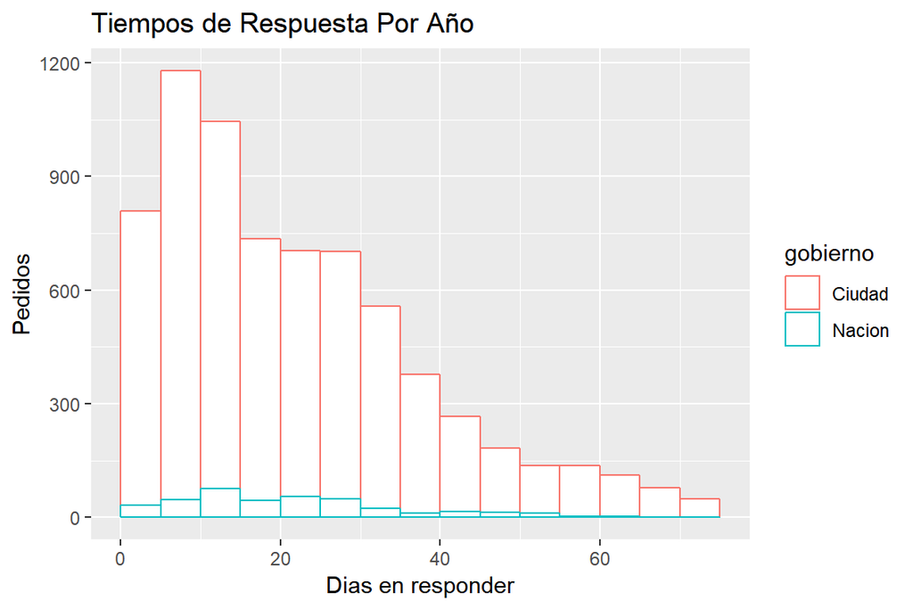

Luego quise entender si la distribución cambio a lo largo del tiempo, para ambos gobiernos. En el caso de Nación, se puede observar que los casos desde le 2013 al 2016 fueron muy escasos, y del 2017 en adelante, si bien la cantidad aumentó, los tiempos de respuesta se mantuvieron uniformes entre 0 y 25 días

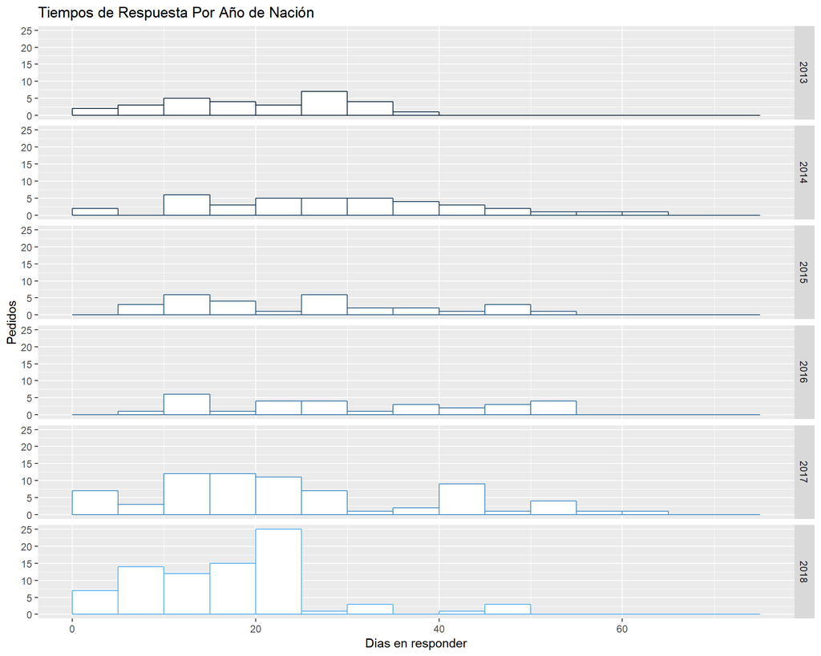

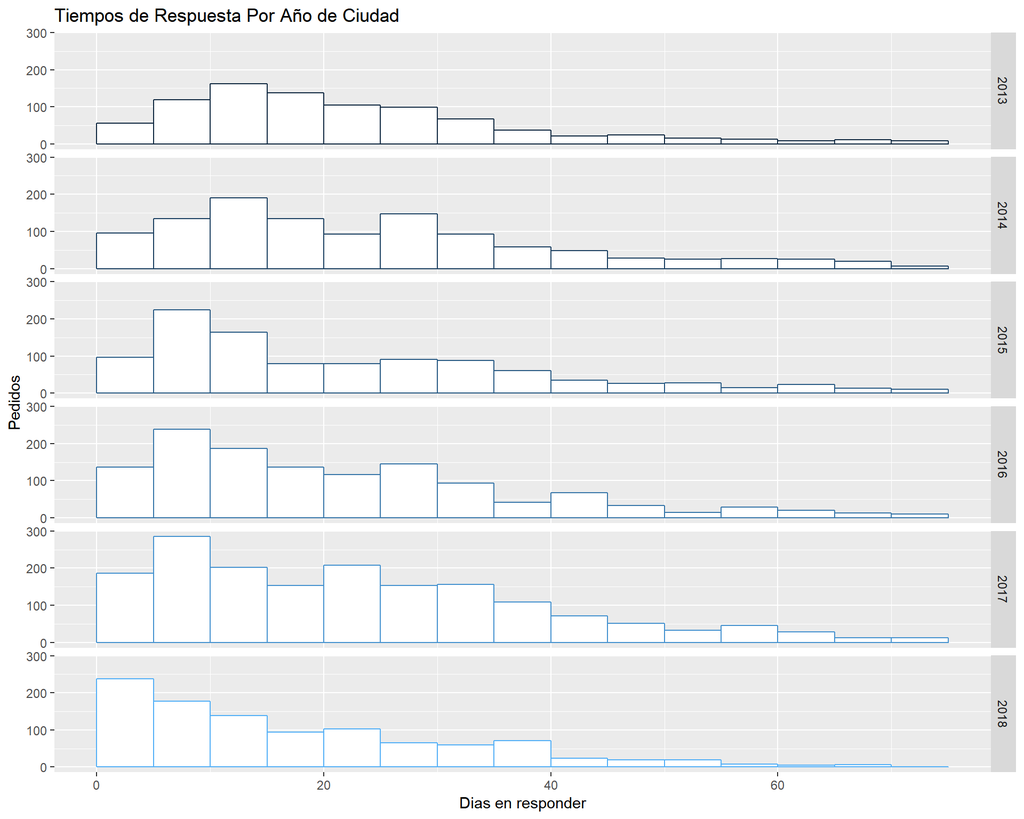

### Evolución de la cantidad de pedidos

Por último, me interesaba saber si la cantidad de pedidos fue cambiando en el tiempo. En nación podemos ver como la cantidad de pedidos mantuvo una tendencia lineal hasta el año 2017, a partir de ahi su demanda creció exponencialmente.

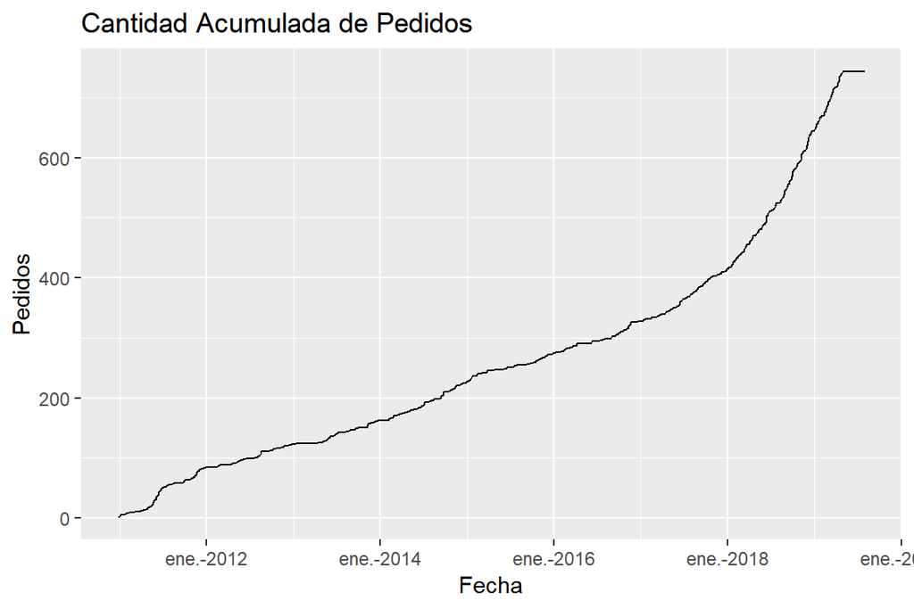

Luego, si lo dividimos por las areas con más pedidos, se observa que a partir del 2017 aumentó la cantidad de pedidos al INADI, que los pedidos a Oficina Anticorrupcón se estancaron desde el 2016 y volvieron a auemntar en el 2018 y que los pedidos a Secretaría de Justicia fueron desacelerando hacia el 2016.

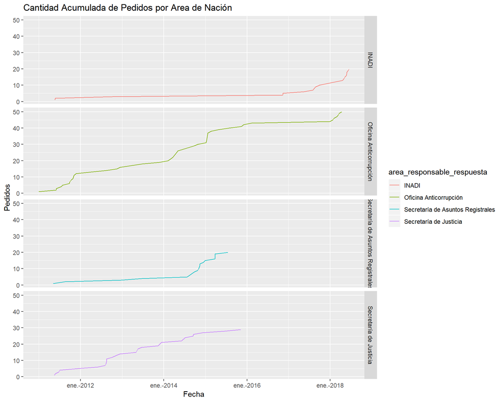

Por otro lado, los pedidos a Ciudad recien vieron un aumento en la tendencia a mediados del 2018.

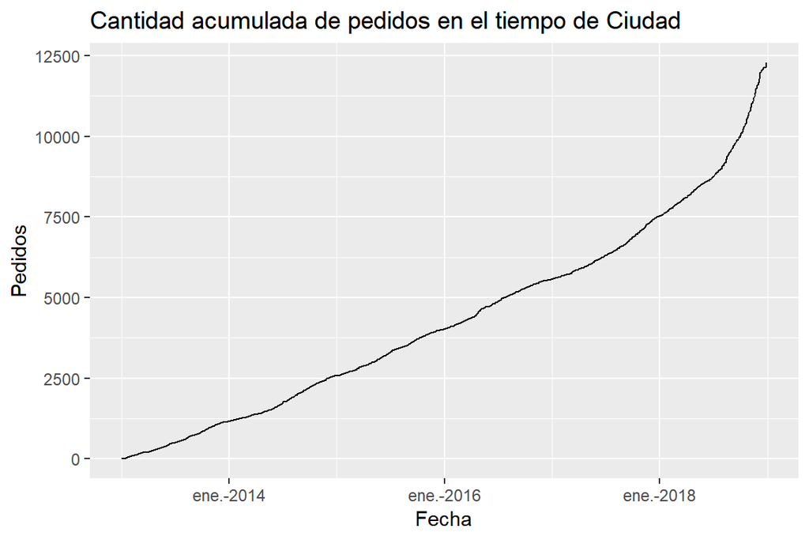

Y en cuanto lo dividimos por areas, podemos observar que la AGC del Ministerio de Justicia y Seguridad tuvo muchisimos pedidos a partir del 2018, mientras que la DGHYP de la AGC es la que mas pedidos tiene año a año desde el 2013, y su pendiente se mantiene constante, al igual que la DGTAL de Ambiente y Espacio publico solo que esta ultima en menores cantidades.

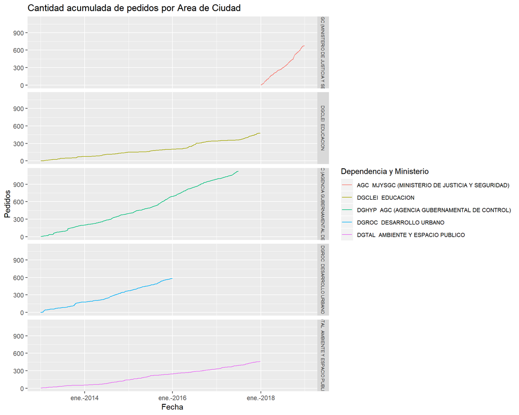